# Er det høyde som bestemmer inntekt?

Assignment 2 - MSB 105

Ole Alexander Bakkevik & Sindre M. Espedal

# Introduksjon

I dette assignmentet skal vi besvare på problemstillingen “*er det høyde som bestemmer inntekt?*”. Vi benytter datasettet **heights** i pakken **modelr** for å svare på problemstillingen.

# Litteraturgjennomgang

Det argumenteres for at fysiske egenskaper spiller en sentral rolle i interaksjoner og resultater i arbeidslivet og det er aktiv litteratur som fokuserer på hvordan attraktivitet, vekt og kroppsbilde påvirker interaksjoner og resultater på arbeidsplassen (Judge og Cable, 2004). For eksempel høyere individer vurderes som mer overbevisende (Young og French, 1996) og mer attraktive som kamerater (Freedman, 1980).

Hensley noterte seg at oppfatningen av at høyere individer er på en eller annen måte mer kapable, dyktige eller mer kompetente ser ut til å stemme (Hensley, 1993). Denne påstanden kan styrkes i det Lester og Sheehan fant ut at sjefene sin forventning var at korte politifolk skulle motta flere klager, forårsake flere displinære problemer og skape dårligere moral enn det høyere politifolk ville gjort (Lester og Sheehan, 1980).

Studier har vist at folk oppfatter verdifulle ting som større enn mindre verdifulle ting; for eksempel oppfattes mynter som er større enn pappskiver med identisk diameter (Judge og Cable, 2004). Denne skjevheten strekker seg også til vurderingen om individers høyde og verdsettelse.

Dette styrkes gjennom en studie av kanadiske velgere, der de viste at etter valget i 1988, bedømte velgerne vinneren (Brian Mulroney) til å være høyere enn før valget. I tillegg bedømte velgerne taperne til å være kortere enn før valget (Judge og Cable, 2004). Høyde er også en metafor for betydningen av makt (Judge og Cable, 2004) og er ofte brukt som en “*heuristikk for dominans*” (Young og French, 1998). I språket er også høyde av sosial verdi. Når en person er høyt aktet, kan han beskrives som en “*stor mann*”, og vi “*Ser opp*” til og beundrer de høye individene (Frieze et al., 1990).

I studien “*The Effect of Physical Height on Workplace Success and Income: Preliminary Test of a Theoretical Model*” fokuserer de på hvilken rolle egenskapen høyde har på suksess i arbeidslivet. I studien kommer det frem at resultatene som er presentert i artikkelen tyder tydelig på at fysisk høyde påvirker folk karrier og interaksjoner på arbeidsplassen og er derfor verdig til fortsatt vitenskapelig undersøkelse (Judge og Cable, 2004).

# Datasettet

Som nevnt bruker vi datasettet **heights** i pakken **modelr**, men siden dataene er amerikanske, er måleenhetene av amerikanske verdier. Vi konverterer dermed først til det metriske systemet som vi bruker i Norge slik at resultatene av analysene skal gi bedre forståelse. I tillegg konverterer vi inntekten fra dollar til norske kroner.

```
##      income             height         weight           age
##  Min.   :     0.0   Min.   :52.0   Min.   : 76.0   Min.   :47.00
##  1st Qu.:   165.5   1st Qu.:64.0   1st Qu.:157.0   1st Qu.:49.00
##  Median : 29589.5   Median :67.0   Median :184.0   Median :51.00
##  Mean   : 41203.9   Mean   :67.1   Mean   :188.3   Mean   :51.33
##  3rd Qu.: 55000.0   3rd Qu.:70.0   3rd Qu.:212.0   3rd Qu.:53.00
##  Max.   :343830.0   Max.   :84.0   Max.   :524.0   Max.   :56.00
##                                    NA's   :95
##       marital         sex         education          afqt
##  single   :1124   male  :3402   Min.   : 1.00   Min.   :  0.00
##  married  :3806   female:3604   1st Qu.:12.00   1st Qu.: 15.12
##  separated: 366                 Median :12.00   Median : 36.76
##  divorced :1549                 Mean   :13.22   Mean   : 41.21
##  widowed  : 161                 3rd Qu.:15.00   3rd Qu.: 65.24
##                                 Max.   :20.00   Max.   :100.00
##                                 NA's   :10      NA's   :262
```

|  | income | height | weight | age | marital | sex | education | afqt |
| --- | --- | --- | --- | --- | --- | --- | --- | --- |
|  | Min. : 0.0 | Min. :52.0 | Min. : 76.0 | Min. :47.00 | single :1124 | male :3402 | Min. : 1.00 | Min. : 0.00 |
|  | 1st Qu.: 165.5 | 1st Qu.:64.0 | 1st Qu.:157.0 | 1st Qu.:49.00 | married :3806 | female:3604 | 1st Qu.:12.00 | 1st Qu.: 15.12 |
|  | Median : 29589.5 | Median :67.0 | Median :184.0 | Median :51.00 | separated: 366 | NA | Median :12.00 | Median : 36.76 |
|  | Mean : 41203.9 | Mean :67.1 | Mean :188.3 | Mean :51.33 | divorced :1549 | NA | Mean :13.22 | Mean : 41.21 |
|  | 3rd Qu.: 55000.0 | 3rd Qu.:70.0 | 3rd Qu.:212.0 | 3rd Qu.:53.00 | widowed : 161 | NA | 3rd Qu.:15.00 | 3rd Qu.: 65.24 |
|  | Max. :343830.0 | Max. :84.0 | Max. :524.0 | Max. :56.00 | NA | NA | Max. :20.00 | Max. :100.00 |
|  | NA | NA | NA’s :95 | NA | NA | NA | NA’s :10 | NA’s :262 |

I tillegg forenkler vi variabelen *marital*. Vi forenkler dette ved å kun benytte gift, eller ikke-gift istedenfor flere alternativer som f.eks *singel, skilt, enke* osv.

Nå er sivistatusen *married* satt som TRUE, og alle andre kategoriene i den nye variabelen er FALSE. Da måles det kun om man er gift eller ikke.

# Beskrivende statistikk

Variablene i dattasettet **heights**, samt verdiene og målingene er hentet fra helpfunksjonen i R og disse variablene er:

Income

- Årlig inntekt. Topp 2% er gjennomsnittet av dem.

Height

- Høyde, i inches (amerikansk måleenhet)

Weight

- Vekt, i pounds (amerikansk måleenhet)

Age

- Alder, i år, mellom 47 og 56

Marital

- Sivilstatus

Sex

- Kjønn

Education

- År med utdannelse

Afqt

- Prosentscore på en “*IQ test*”.

Variablene i datasettet **hoyde** er like, i tillegg til noen ekstra variabler:

inntekt_kr

- Årlig inntekt, målt i norske kroner.

hoyde_cm

- Høyde, målt i centimeter.

vekt_kg

- Vekt, målt i kilogram.

bmi

- Body-mass-index

married

- Gift eller ikke-gift

# EDA

Illustrasjon over *inntek_kr*.

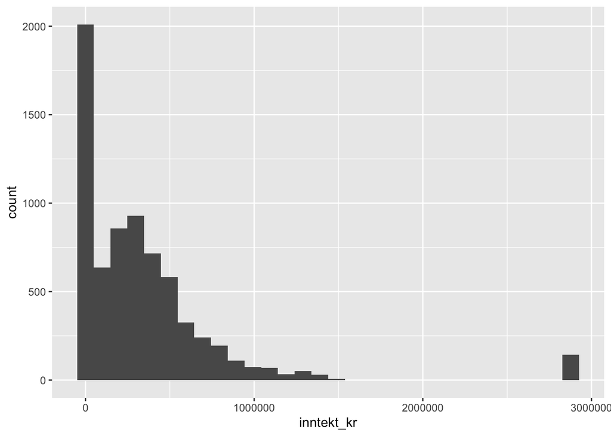

Uteliggerne til høyre skyldes at det er noen få som tjener veldig mye. Disse er summert sammen og utregnet gjennomsnittet på dem. Dette er på grunn av personverns-årsaker.

```
## [1] 1740
```

Vi har 1 740 observasjoner som har inntekt lik 0.

# Regresjonsanalyse

Alle nye- og forenklede variabler er lagt inn fra før. Det samme gjelder konverteringene.

Den første modellen er en veldig enkel regresjonsmodell som ser kun på hvordan høyden påvirker inntekten.

```
##
## Call:
## lm(formula = modell_1, data = hoyde)
##
## Residuals:
##     Min      1Q  Median      3Q     Max
## -766554 -263745  -91173  124563 2685330
##
## Coefficients:
##               Estimate Std. Error t value            Pr(>|t|)
## (Intercept) -1329893.0    89841.5  -14.80 <0.0000000000000002 ***
## hoyde_cm        9825.9      526.1   18.68 <0.0000000000000002 ***
## ---
## Signif. codes:  0 '***' 0.001 '**' 0.01 '*' 0.05 '.' 0.1 ' ' 1
##
## Residual standard error: 456600 on 7004 degrees of freedom
## Multiple R-squared:  0.04744,    Adjusted R-squared:  0.0473
## F-statistic: 348.8 on 1 and 7004 DF,  p-value: < 0.00000000000000022
```

Ut i fra denne enkle regresjonen i **modell_1** ser vi at hvis vi øker høyden med én ekstra centimeter, så øker årlig lønn med 9825.9kr. Den uttrykkes også som signifikant, men forklaringsvariansen er kun på 4,7% som vil si at 95,3% av modellen kan ikke forklares gjennom regresjonen ($u$). Derfor er dette egentlig en veldig dårlig modell.

I neste modell legger vi til en ekstra variabel, variabelen *vekt_kg*, for å se hvordan dette påvirker regresjonsmodellen.

```
##
## Call:
## lm(formula = modell_2, data = hoyde)
##
## Residuals:
##     Min      1Q  Median      3Q     Max
## -828525 -258745  -90442  124446 2701163
##
## Coefficients:
##               Estimate Std. Error t value             Pr(>|t|)
## (Intercept) -1441826.3    93195.8 -15.471 < 0.0000000000000002 ***
## hoyde_cm       11226.7      600.5  18.696 < 0.0000000000000002 ***
## vekt_kg        -1481.3      309.0  -4.794           0.00000167 ***
## ---
## Signif. codes:  0 '***' 0.001 '**' 0.01 '*' 0.05 '.' 0.1 ' ' 1
##
## Residual standard error: 458000 on 6908 degrees of freedom
##   (95 observations deleted due to missingness)
## Multiple R-squared:  0.05077,    Adjusted R-squared:  0.0505
## F-statistic: 184.7 on 2 and 6908 DF,  p-value: < 0.00000000000000022
```

I **modell_2** påvirker *vekt_kg* negativt på *inntekt_kr*. Hvis *vekt_kg* øker med én ekstra kg, så reduseres årlig *inntekt_kr* 1481.3kr. Denne variabelen er også signifikant, men forklaringsvariansen på overkant av 5% indikerer at **modell_2** er også en dårlig modell, ettersom den har en liten forklaring.

I **modell_3** legges det til en ytterligere variabel, variabelen *bmi*.

```
##
## Call:
## lm(formula = modell_3, data = hoyde)
##
## Residuals:
##     Min      1Q  Median      3Q     Max
## -864541 -257416  -91679  124029 2696877
##
## Coefficients:
##             Estimate Std. Error t value     Pr(>|t|)
## (Intercept) -1907489     427914  -4.458 0.0000084174 ***
## hoyde_cm       13972       2534   5.513 0.0000000365 ***
## vekt_kg        -4198       2456  -1.709       0.0874 .
## bmi             7834       7026   1.115       0.2649
## ---
## Signif. codes:  0 '***' 0.001 '**' 0.01 '*' 0.05 '.' 0.1 ' ' 1
##
## Residual standard error: 458000 on 6907 degrees of freedom
##   (95 observations deleted due to missingness)
## Multiple R-squared:  0.05094,    Adjusted R-squared:  0.05053
## F-statistic: 123.6 on 3 and 6907 DF,  p-value: < 0.00000000000000022
```

Ut i fra **modell_3** så ser vi at hvis *bmi* øker med én ekstra enhet, så øker årlig *inntekt_kr* med 7834kr.

**modell_3** viser 3 variabler hvor *hoyde_cm* er den eneste signifikante variabelen med et konfidensintervall på 95%. Likevel har forklaringsvariansen hatt en minimal økning på en ellers så svært liten forklaringskraft.

I **modell_4** legges variablene *education* og *age* til i regresjonsmodellen.

```
##
## Call:
## lm(formula = modell_4, data = hoyde)
##
## Residuals:
##     Min      1Q  Median      3Q     Max
## -994470 -230101  -57569  124319 2855576
##
## Coefficients:
##             Estimate Std. Error t value             Pr(>|t|)
## (Intercept) -2603720     413936  -6.290       0.000000000337 ***
## hoyde_cm       13468       2344   5.745       0.000000009591 ***
## vekt_kg        -4736       2272  -2.084               0.0372 *
## bmi            11853       6505   1.822               0.0685 .
## education      68611       1964  34.934 < 0.0000000000000002 ***
## age            -3815       2276  -1.676               0.0937 .
## ---
## Signif. codes:  0 '***' 0.001 '**' 0.01 '*' 0.05 '.' 0.1 ' ' 1
##
## Residual standard error: 422300 on 6895 degrees of freedom
##   (105 observations deleted due to missingness)
## Multiple R-squared:  0.1939, Adjusted R-squared:  0.1933
## F-statistic: 331.7 on 5 and 6895 DF,  p-value: < 0.00000000000000022
```

**modell_4** viser at *age* påvirker årlig *inntekt_kr* negativt mens *education* har en positiv effekt. variabelen *education* er også svært signifikant. De 2 ekstra variablene øker forklaringskraften betydelig, helt opp til 19,4%.

## Huxreg

Setter opp en **Huxtable** for å vise en oversikt over modell 1, 2 og 3.

|  | modell_1 | modell_2 | modell_3 |
| --- | --- | --- | --- |
| (Intercept) | -1329893.035 *** | -1441826.256 *** | -1907488.774 *** |
|  | [-14.803] | [-15.471] | [-4.458] |
| hoyde_cm | 9825.866 *** | 11226.677 *** | 13971.667 *** |
|  | [18.676] | [18.696] | [5.513] |
| vekt_kg |  | -1481.275 *** | -4197.636 |
|  |  | [-4.794] | [-1.709] |
| bmi |  |  | 7833.548 |
|  |  |  | [1.115] |
| N | 7006 | 6911 | 6911 |
| R2 | 0.047 | 0.051 | 0.051 |
| logLik | -101239.507 | -99887.319 | -99886.697 |
| AIC | 202485.014 | 199782.637 | 199783.394 |
| Regresjonstabell 3: *** p < 0.001; ** p < 0.01; * p < 0.05. T statistics in brackets. |  |  |  |

Variabelen *hoyde_cm* er signifikant gjennom alle tre modellene mens *vekt_kg* er kun signifikant i **modell_2**. Variabelen *hoyde_cm* får også en større påvirkning på *inntekt_kr* når flere variabler legges til. Forklaringskraften øker minimalt fra **modell_1**, men den øker ikke mellom **modell_2** og **modell_3**. Forklaringskraften er også veldig liten.

## Interaksjon

Denne modellen har en interaksjon på variabelen *sex*, som vil si en modell for kvinner og menn.

```
##
## Call:
## lm(formula = modell_int, data = hoyde)
##
## Residuals:
##     Min      1Q  Median      3Q     Max
## -844832 -243051  -90336  125765 2664145
##
## Coefficients:
##                           Estimate  Std. Error t value Pr(>|t|)
## (Intercept)            -2296981.00  3061743.05  -0.750    0.453
## sexfemale                364907.00  3877913.34   0.094    0.925
## hoyde_cm                  14177.21    17010.78   0.833    0.405
## vekt_kg                     217.78    29577.95   0.007    0.994
## I(vekt_kg^2)                -29.54       71.13  -0.415    0.678
## bmi                       17853.31    96322.70   0.185    0.853
## I(bmi^2)                    -64.14      767.00  -0.084    0.933
## sexfemale:hoyde_cm          -31.35    22460.23  -0.001    0.999
## sexfemale:vekt_kg        -18273.48    40602.63  -0.450    0.653
## sexfemale:I(vekt_kg^2)       67.20      105.64   0.636    0.525
## sexfemale:bmi             25515.27   120895.62   0.211    0.833
## sexfemale:I(bmi^2)         -193.30      937.66  -0.206    0.837
##
## Residual standard error: 455700 on 6899 degrees of freedom
##   (95 observations deleted due to missingness)
## Multiple R-squared:  0.06166,    Adjusted R-squared:  0.06016
## F-statistic: 41.21 on 11 and 6899 DF,  p-value: < 0.00000000000000022
```

Vi ser fra regresjonsmodellen at dummyen for *sexfemale* og interaksjonsvariablene ikke er signifikante.

# Hypotesetesting

## Test av koeffisientene samt korrelasjon

```
##
## t test of coefficients:
##
##               Estimate Std. Error t value              Pr(>|t|)
## (Intercept) -2603720.2   449564.5 -5.7917        0.000000007276 ***
## hoyde_cm       13468.1     2534.7  5.3136        0.000000110870 ***
## vekt_kg        -4736.3     2379.1 -1.9908               0.04654 *
## bmi            11852.6     6433.8  1.8422               0.06548 .
## education      68611.2     2678.0 25.6207 < 0.00000000000000022 ***
## age            -3814.6     2315.2 -1.6477               0.09947 .
## ---
## Signif. codes:  0 '***' 0.001 '**' 0.01 '*' 0.05 '.' 0.1 ' ' 1
```

```
##                     2.5 %        97.5 %
## (Intercept) -3415162.4005 -1792278.0593
## hoyde_cm        8872.3928    18063.7622
## vekt_kg        -9190.8220     -281.8592
## bmi             -898.8988    24604.0399
## education      64761.0950    72461.3161
## age            -8275.8056      646.5600
```

```
## [1] 0.2177982
```

| Res.Df | RSS | Df | Sum of Sq | F | Pr(>F) |
| --- | --- | --- | --- | --- | --- |
| 6.90e+03 | 1.45e+15 |  |  |  |  |
| 6.9e+03 | 1.43e+15 | 6 | 1.5e+13 | 12 | 1.81e-13 |

```
##
## Call:
## lm(formula = modell_4, data = hoyde)
##
## Residuals:
##     Min      1Q  Median      3Q     Max
## -994470 -230101  -57569  124319 2855576
##
## Coefficients:
##             Estimate Std. Error t value             Pr(>|t|)
## (Intercept) -2603720     413936  -6.290       0.000000000337 ***
## hoyde_cm       13468       2344   5.745       0.000000009591 ***
## vekt_kg        -4736       2272  -2.084               0.0372 *
## bmi            11853       6505   1.822               0.0685 .
## education      68611       1964  34.934 < 0.0000000000000002 ***
## age            -3815       2276  -1.676               0.0937 .
## ---
## Signif. codes:  0 '***' 0.001 '**' 0.01 '*' 0.05 '.' 0.1 ' ' 1
##
## Residual standard error: 422300 on 6895 degrees of freedom
##   (105 observations deleted due to missingness)
## Multiple R-squared:  0.1939, Adjusted R-squared:  0.1933
## F-statistic: 331.7 on 5 and 6895 DF,  p-value: < 0.00000000000000022
```

```
##
## Call:
## lm(formula = modell_int, data = hoyde)
##
## Residuals:
##     Min      1Q  Median      3Q     Max
## -844832 -243051  -90336  125765 2664145
##
## Coefficients:
##                           Estimate  Std. Error t value Pr(>|t|)
## (Intercept)            -2296981.00  3061743.05  -0.750    0.453
## sexfemale                364907.00  3877913.34   0.094    0.925
## hoyde_cm                  14177.21    17010.78   0.833    0.405
## vekt_kg                     217.78    29577.95   0.007    0.994
## I(vekt_kg^2)                -29.54       71.13  -0.415    0.678
## bmi                       17853.31    96322.70   0.185    0.853
## I(bmi^2)                    -64.14      767.00  -0.084    0.933
## sexfemale:hoyde_cm          -31.35    22460.23  -0.001    0.999
## sexfemale:vekt_kg        -18273.48    40602.63  -0.450    0.653
## sexfemale:I(vekt_kg^2)       67.20      105.64   0.636    0.525
## sexfemale:bmi             25515.27   120895.62   0.211    0.833
## sexfemale:I(bmi^2)         -193.30      937.66  -0.206    0.837
##
## Residual standard error: 455700 on 6899 degrees of freedom
##   (95 observations deleted due to missingness)
## Multiple R-squared:  0.06166,    Adjusted R-squared:  0.06016
## F-statistic: 41.21 on 11 and 6899 DF,  p-value: < 0.00000000000000022
```

# Residualene

I den endelige modellen legges variablene *education*, *married*, *sex* og *afqt* til i tillegg. Variabelen *age* legges ikke til fordi aldersspennet er bare mellom 9 år, noe som ikke er særlig stor variasjon. Fullstendige modellen blir dermed seende slik ut:

```
##
## Call:
## lm(formula = modell_f, data = hoyde)
##
## Residuals:
##     Min      1Q  Median      3Q     Max
## -975293 -210118  -43707  125388 2758733
##
## Coefficients:
##             Estimate Std. Error t value             Pr(>|t|)
## (Intercept) -1554319     404900  -3.839             0.000125 ***
## hoyde_cm        7114       2387   2.980             0.002889 **
## vekt_kg        -6529       2265  -2.883             0.003956 **
## bmi            17534       6471   2.710             0.006755 **
## education      49489       2419  20.456 < 0.0000000000000002 ***
## marriedTRUE    88747      10450   8.493 < 0.0000000000000002 ***
## afqt            3313        221  14.993 < 0.0000000000000002 ***
## sexfemale    -204806      14542 -14.083 < 0.0000000000000002 ***
## ---
## Signif. codes:  0 '***' 0.001 '**' 0.01 '*' 0.05 '.' 0.1 ' ' 1
##
## Residual standard error: 411000 on 6637 degrees of freedom
##   (361 observations deleted due to missingness)
## Multiple R-squared:  0.255,  Adjusted R-squared:  0.2542
## F-statistic: 324.5 on 7 and 6637 DF,  p-value: < 0.00000000000000022
```

Så kjører vi den fullstendige modellen og begrenser den med å fjerne de 2% høyeste inntektene og de som har null i inntekt.

```
##
## Call:
## lm(formula = modell_f, data = hoyde_b)
##
## Residuals:
##     Min      1Q  Median      3Q     Max
## -714122 -155634  -29517  117375 1102390
##
## Coefficients:
##              Estimate Std. Error t value             Pr(>|t|)
## (Intercept) -103335.1   295314.0  -0.350                0.726
## hoyde_cm        170.8     1734.2   0.098                0.922
## vekt_kg         261.5     1637.6   0.160                0.873
## bmi           -1451.0     4720.1  -0.307                0.759
## education     32413.1     1650.2  19.642 < 0.0000000000000002 ***
## marriedTRUE   46570.6     7171.1   6.494      0.0000000000918 ***
## afqt           1992.6      149.0  13.373 < 0.0000000000000002 ***
## sexfemale   -130192.0    10156.9 -12.818 < 0.0000000000000002 ***
## ---
## Signif. codes:  0 '***' 0.001 '**' 0.01 '*' 0.05 '.' 0.1 ' ' 1
##
## Residual standard error: 241200 on 4863 degrees of freedom
##   (252 observations deleted due to missingness)
## Multiple R-squared:  0.2605, Adjusted R-squared:  0.2595
## F-statistic: 244.8 on 7 and 4863 DF,  p-value: < 0.00000000000000022
```

Ved å fjerne 2% høyeste inntekt og de som har null i inntekt mister *hoyde_cm* sin signifikans.

Legger til residualene fra endelig modell fra datasettet

| income | height | weight | age | marital | sex | education | afqt | hoyde_cm | vekt_kg | inntekt_kr | bmi | married | resid |
| --- | --- | --- | --- | --- | --- | --- | --- | --- | --- | --- | --- | --- | --- |
| 19000 | 60 | 155 | 53 | married | female | 13 | 6.84 | 152 | 70.3 | 1.59e+05 | 30.2710513455749 | TRUE | -8.95e+04 |
| 35000 | 70 | 156 | 51 | married | female | 10 | 49.4 | 178 | 70.8 | 2.93e+05 | 22.3834396783079 | TRUE | 4.09e+04 |
| 105000 | 65 | 195 | 52 | married | male | 16 | 99.4 | 165 | 88.5 | 8.79e+05 | 32.449365214115 | TRUE | 2.15e+05 |
| 40000 | 63 | 197 | 54 | married | female | 14 | 44 | 160 | 89.4 | 3.35e+05 | 34.896625645985 | TRUE | -1.98e+04 |
| 75000 | 66 | 190 | 49 | married | male | 14 | 59.7 | 168 | 86.2 | 6.28e+05 | 30.6664876334803 | TRUE | 1.05e+05 |

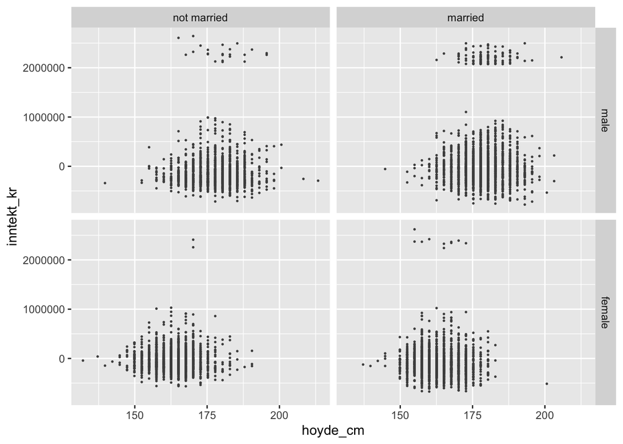

# Konklusjon

Variabelen *hoyde_cm* blir usignifikant med det begrensede datasettet ved å fjerne de 2% høyeste inntektene og de som har null i inntekt.

Vi kan dermed **ikke** påstå at det er høyde som bestemmer inntekt.

# Litteraturliste

Freedman, D. G. (1980). The Social and the Biological: A Necessary Unity. *Zygon*, *15*(2), 117–131. https://doi.org/10.1111/j.1467-9744.1980.tb00381.x

Frieze, I. H., Olson, J. E., og Good, D. C. (1990). Perceived and Actual Discrimination in the Salaries of Male and Female Managers. *Journal of Applied Social Psychology*, *20*(1), 46–67. https://doi.org/10.1111/j.1559-1816.1990.tb00377.x

Hensley, W. E. (1993). Height as a Measure of Success in Academe. *Psychology: A Journal of Human Behavior*, *30*(1), 40–46.

Judge, T. A., og Cable, D. M. (2004). The Effect of Physical Height on Workplace Success and Income: Preliminary Test of a Theoretical Model. *The Journal of Applied Psychology*, *89*(3), 428–441. https://doi.org/10.1037/0021-9010.89.3.428

Lester, D., og Sheehan, D. (1980). Attitudes of Supervisors toward Short Police Officers. *Psychological Reports*, *47*(2), 462–462. https://doi.org/10.2466/pr0.1980.47.2.462

Young, T. J., og French, L. A. (1996). Height and Perceived Competence of US Presidents. *Perceptual and Motor Skills*, *82*(3 Pt 1), 1002. https://doi.org/10.1177/003151259608200301

Young, T. J., og French, L. A. (1998). Heights of U.S. Presidents: A Trend Analysis for 1948. *Perceptual and Motor Skills*, *87*(1), 321–322. https://doi.org/10.2466/pms.1998.87.1.321